# BoTorch · Bayesian Optimization in PyTorch

## BoTorch

### 0.5.1

## Composite Bayesian Optimization with the High Order Gaussian Process

In this tutorial, we're going to explore composite Bayesian optimization [Astudillo & Frazier, ICML, '19](https://proceedings.mlr.press/v97/astudillo19a.html) with the High Order Gaussian Process (HOGP) model of [Zhe et al, AISTATS, '19](http://proceedings.mlr.press/v89/zhe19a.html). The setup for composite Bayesian optimization is that we have an unknown (black box) function mapping input parameters to several outputs, and a second, known function describing the quality of the functional output. We wish to find input parameters that maximize the output metric function. We wish to find input parameters that maximize the output metric function in a black-box manner.

Specifically, this can be described as $\max_{x \in \mathcal{X}} g(f(x)),$ where $f$ is unknown and $g$ is known. As in traditional Bayesian optimization, we are going to construct a Gaussian process surrogate model over the expensive to evaluate function $f(.),$ and will use a HOGP to model this function.

### HOGP model description

The [High Order Gaussian Process (HOGP) model](https://proceedings.mlr.press/v89/zhe19a.html) is a Gaussian process model designed specifically to operate over tensors or multi-dimensional arrays and exploits structure in the tensor to be able to operate efficiently. Specifically, the HOGP takes as inputs $y \in \mathbb{R}^{N \times d_2 \times \cdots \times d_M}$ and assumes that $\text{vec}(y) \sim \mathcal{N}(0, \otimes_{i=1}^M K_i + \sigma^2 I),$ where $K_1 = K_{XX}.$ Each dimension of the tensor has its own kernel function, $K_i,$ as well as a set of $d_i$ latent parameters that can be optimized over.

Recently, [Maddox et al, '21](https://arxiv.org/abs/2106.12997) proposed a method for computing posterior samples from the HOGP by exploiting structure in the posterior distribution, thereby enabling its usage in BO settings. While they show that this approach allows to use composite BO on problems with tens or thousands of outputs, for scalability we consider a much smaller example here (that does not require GPU acceleration).

```python
import torch
import os
import logging
import numpy as np
import math
import matplotlib.pyplot as plt
import time

import gpytorch.settings as gpt_settings

from botorch.acquisition import qSimpleRegret, qExpectedImprovement
from botorch.acquisition.objective import GenericMCObjective
from botorch.models import HigherOrderGP, SingleTaskGP
from botorch.models.higher_order_gp import FlattenedStandardize
from botorch.models.transforms import Normalize, Standardize
from botorch import fit_gpytorch_model
from botorch.optim import optimize_acqf
from botorch.sampling import IIDNormalSampler
from botorch.utils.sampling import draw_sobol_samples

from gpytorch.mlls import ExactMarginalLogLikelihood

SMOKE_TEST = os.environ.get("SMOKE_TEST")
```

```python
from botorch.optim.fit import fit_gpytorch_torch
```

#### Set Device and dtype

```python
device = torch.device("cpu") if not torch.cuda.is_available() else torch.device("cuda:0")
dtype = torch.float

print("Using ", device)
```

```
Using  cuda:0
```

```python
models_used = (
    "rnd",
    "ei",
    "ei_hogp_cf",
)
```

### Problem Description

We use a simple test problem describing the concentration of pollutants after a chemical spill from [Astudillo & Frazier, ICML, '19](https://proceedings.mlr.press/v97/astudillo19a.html) defined over a $3 \times 4$ grid of values $s,t$ and we wish to optimize the parameters w.r.t. their true values, to estimate the true value of parameters, $x = [M, D, L, \tau].$ The function is given by $$ f(s,t | M, D, L, \tau) := \frac{M}{\sqrt{4 \pi D t}} \exp\{-\frac{s^2}{4Dt}\} + \frac{1_{t > \tau} M}{\sqrt{4 \pi D(t - \tau)}} \exp\{- \frac{(s - L)^2}{4 D (t - \tau)}\}, $$ with the cheap to evaluate, differentiable function given by $g(y):= \sum_{(s,t) \in S \times T} \left(c(s, t|x_{\text{true}}) - y\right)^2.$ As the objective function itself is going to be implemented in Pytorch, we will be able to differentiate through it, enabling the usage of gradient-based optimization to optimize the objectives with respect to the inputs.

```python
def env_cfun(s, t, M, D, L, tau):
    c1 = M / torch.sqrt(4 * math.pi * D * t)
    exp1 = torch.exp(-(s ** 2) / 4 / D / t)
    term1 = c1 * exp1
    c2 = M / torch.sqrt(4 * math.pi * D * (t - tau))
    exp2 = torch.exp(-((s - L) ** 2) / 4 / D / (t - tau))
    term2 = c2 * exp2
    term2[torch.isnan(term2)] = 0.0
    return term1 + term2
```

#### Helper Functions

These are helper functions for us to maximize the acquisition function and to get random points.

```python
def gen_rand_points(bounds, num_samples):
    points_nlzd = torch.rand(num_samples, bounds.shape[-1]).to(bounds)
    return bounds[0] + (bounds[1] - bounds[0]) * points_nlzd


def optimize_ei(qEI, bounds, **options):
    with gpt_settings.fast_computations(covar_root_decomposition=False):
        cands_nlzd, _ = optimize_acqf(
                qEI, bounds, **options,
        )
    return cands_nlzd
```

Below is a wrapped function to help us define bounds on the parameter space, we can also vary the size of the grid if we'd like to.

```python
def prepare_data(s_size=3, t_size=4, device=device, dtype=dtype):
    print("---- Running the environmental problem with ", s_size, t_size, " ----")
    # X = [M, D, L, tau]
    bounds = torch.tensor(
        [[7.0, 0.02, 0.01, 30.010], [13.0, 0.12, 3.00, 30.295]],
        device=device,
        dtype=dtype,
    )

    M0 = torch.tensor(10.0, device=device, dtype=dtype)
    D0 = torch.tensor(0.07, device=device, dtype=dtype)
    L0 = torch.tensor(1.505, device=device, dtype=dtype)
    tau0 = torch.tensor(30.1525, device=device, dtype=dtype)

    # we can vectorize everything, no need for loops
    if s_size == 3:
        S = torch.tensor([0.0, 1.0, 2.5], device=device, dtype=dtype)
    else:
        S = torch.linspace(0.0, 2.5, s_size, device=device, dtype=dtype)
    if t_size == 4:
        T = torch.tensor([15.0, 30.0, 45.0, 60.0], device=device, dtype=dtype)
    else:
        T = torch.linspace(15.0, 60.0, t_size, device=device, dtype=dtype)

    Sgrid, Tgrid = torch.meshgrid(S, T)

    # X = [M, D, L, tau]
    def c_batched(X, k=None):
        return torch.stack([env_cfun(Sgrid, Tgrid, *x) for x in X])

    c_true = env_cfun(Sgrid, Tgrid, M0, D0, L0, tau0)

    def neq_sum_quared_diff(samples):
        # unsqueeze
        if samples.shape[-1] == (s_size * t_size):
            samples = samples.unsqueeze(-1).reshape(
                *samples.shape[:-1], s_size, t_size
            )

        sq_diffs = (samples - c_true).pow(2)
        return sq_diffs.sum(dim=(-1, -2)).mul(-1.0)

    objective = GenericMCObjective(neq_sum_quared_diff)
    num_samples = 32

    return c_batched, objective, bounds, num_samples
```

In the above, we construct a `GenericMCObjective` instance to codify the objective function (which is minimizing the MSE of the output tensors and the outputs corresponding to the "true" parameter values). Note that the objective function is encoded in PyTorch and is differentiable (although it technically doesn't have to be). Ultimately, we backpropagate through the objective with respect to the input parameters (and through the HOGP as well).

## BO Loop

Finally, we run the BO loop over three trials for $15$ batches each. This loop might take a while.

We will be comparing to both random selection and batch expected improvment on the aggregated metric.

```python
n_init = 30

if SMOKE_TEST:
    n_batches = 1
    batch_size = 2
    n_trials = 1
else:
    n_batches = 15
    batch_size = 4
    n_trials = 3
```

As a word of caution, we've found that when fitting the HOGP model, using first-order optimizers (e.g. Adam) as is used in `fit_gpytorch_torch` tends to outperform second-order optimizers such as L-BFGS-B due to the large number of free parameters in the HOGP. L-BFGS-B tends to overfit in practice here.

```python
all_objective_vals = []

with gpt_settings.cholesky_jitter(1e-4):
    for trial in range(n_trials):
        print("Beginning with trial: ", trial+1)
        c_batched, objective, bounds, num_samples = prepare_data(device=device, dtype=dtype)

        train_X_init = gen_rand_points(bounds, n_init)
        train_Y_init = c_batched(train_X_init)

        # these will keep track of the points explored
        train_X = {k: train_X_init.clone() for k in models_used}
        train_Y = {k: train_Y_init.clone() for k in train_X}

        # run the BO loop
        for i in range(n_batches):
            tic = time.time()

            # get best observations, log status
            best_f = {k: objective(v).max().detach() for k, v in train_Y.items()}

            logging.info(
                f"It {i+1:>2}/{n_batches}, best obs.: "
                ", ".join([f"{k}: {v:.3f}" for k, v in best_f.items()])
            )

            # generate random candidates
            cands = {}
            cands["rnd"] = gen_rand_points(bounds, batch_size)

            optimize_acqf_kwargs = {
                "q": batch_size,
                "num_restarts": 10,
                "raw_samples": 512,
            }
            sampler = IIDNormalSampler(num_samples=128)

            train_Y_ei = objective(train_Y["ei"]).unsqueeze(-1)
            model_ei = SingleTaskGP(
                train_X["ei"],
                train_Y_ei,
                input_transform=Normalize(train_X["ei"].shape[-1]),
                outcome_transform=Standardize(train_Y_ei.shape[-1]),
            )

            mll = ExactMarginalLogLikelihood(model_ei.likelihood, model_ei)
            fit_gpytorch_torch(mll, options={"lr": 0.01, "maxiter": 3000, "disp": False})

            # generate qEI candidate (single output modeling)
            qEI = qExpectedImprovement(model_ei, best_f=best_f["ei"], sampler=sampler)
            cands["ei"] = optimize_ei(qEI, bounds, **optimize_acqf_kwargs)

            model_ei_hogp_cf = HigherOrderGP(
                train_X["ei_hogp_cf"],
                train_Y["ei_hogp_cf"],
                outcome_transform=FlattenedStandardize(train_Y["ei_hogp_cf"].shape[1:]),
                input_transform=Normalize(train_X["ei_hogp_cf"].shape[-1]),
                latent_init="gp",
            )

            mll = ExactMarginalLogLikelihood(model_ei_hogp_cf.likelihood, model_ei_hogp_cf)
            fit_gpytorch_torch(mll, options={"lr": 0.01, "maxiter": 3000, "disp": False})

            # generate qEI candidate (multi-output modeling)
            qEI_hogp_cf = qExpectedImprovement(
                model_ei_hogp_cf,
                best_f=best_f["ei_hogp_cf"],
                sampler=sampler,
                objective=objective,
            )
            cands["ei_hogp_cf"] = optimize_ei(qEI_hogp_cf, bounds, **optimize_acqf_kwargs)

            # make observations and update data
            for k, Xold in train_X.items():
                Xnew = cands[k]
                if Xnew.shape[0] > 0:
                    train_X[k] = torch.cat([Xold, Xnew])
                    train_Y[k] = torch.cat([train_Y[k], c_batched(Xnew)])

            logging.info(f"Wall time: {time.time() - tic:1f}")

        objective_dict = {k: objective(train_Y[k]) for k in train_Y}
        all_objective_vals.append(objective_dict)
        print("Finished with trial: ", trial+1)
```

```
Beginning with trial:  1
---- Running the environmental problem with  3 4  ----
```

```
I0712 100259.916 <ipython-input-9-289fa74c7767>:22] rnd: -0.277It  1/15, best obs.: , ei: -0.277It  1/15, best obs.: , ei_hogp_cf: -0.277
I0712 100313.875 <ipython-input-9-289fa74c7767>:80] Wall time: 13.959815
I0712 100313.876 <ipython-input-9-289fa74c7767>:22] rnd: -0.277It  2/15, best obs.: , ei: -0.277It  2/15, best obs.: , ei_hogp_cf: -0.277
I0712 100331.374 <ipython-input-9-289fa74c7767>:80] Wall time: 17.497971
I0712 100331.375 <ipython-input-9-289fa74c7767>:22] rnd: -0.277It  3/15, best obs.: , ei: -0.277It  3/15, best obs.: , ei_hogp_cf: -0.277
I0712 100351.131 <ipython-input-9-289fa74c7767>:80] Wall time: 19.756105
I0712 100351.132 <ipython-input-9-289fa74c7767>:22] rnd: -0.277It  4/15, best obs.: , ei: -0.277It  4/15, best obs.: , ei_hogp_cf: -0.277
I0712 100423.226 <ipython-input-9-289fa74c7767>:80] Wall time: 32.094512
I0712 100423.228 <ipython-input-9-289fa74c7767>:22] rnd: -0.277It  5/15, best obs.: , ei: -0.277It  5/15, best obs.: , ei_hogp_cf: -0.277
I0712 100454.340 <ipython-input-9-289fa74c7767>:80] Wall time: 31.112883
I0712 100454.342 <ipython-input-9-289fa74c7767>:22] rnd: -0.277It  6/15, best obs.: , ei: -0.277It  6/15, best obs.: , ei_hogp_cf: -0.219
I0712 100554.118 <ipython-input-9-289fa74c7767>:80] Wall time: 59.776674
I0712 100554.119 <ipython-input-9-289fa74c7767>:22] rnd: -0.277It  7/15, best obs.: , ei: -0.277It  7/15, best obs.: , ei_hogp_cf: -0.137
I0712 100649.414 <ipython-input-9-289fa74c7767>:80] Wall time: 55.294851
I0712 100649.415 <ipython-input-9-289fa74c7767>:22] rnd: -0.277It  8/15, best obs.: , ei: -0.277It  8/15, best obs.: , ei_hogp_cf: -0.076

A not p.d., added jitter of 1.0e-04 to the diagonal

I0712 100659.421 <ipython-input-9-289fa74c7767>:80] Wall time: 10.006811
I0712 100659.423 <ipython-input-9-289fa74c7767>:22] rnd: -0.277It  9/15, best obs.: , ei: -0.277It  9/15, best obs.: , ei_hogp_cf: -0.076
I0712 100713.541 <ipython-input-9-289fa74c7767>:80] Wall time: 14.118601
I0712 100713.543 <ipython-input-9-289fa74c7767>:22] rnd: -0.277It 10/15, best obs.: , ei: -0.277It 10/15, best obs.: , ei_hogp_cf: -0.076
I0712 100725.215 <ipython-input-9-289fa74c7767>:80] Wall time: 11.672525
I0712 100725.216 <ipython-input-9-289fa74c7767>:22] rnd: -0.277It 11/15, best obs.: , ei: -0.277It 11/15, best obs.: , ei_hogp_cf: -0.076
I0712 100733.256 <ipython-input-9-289fa74c7767>:80] Wall time: 8.040162
I0712 100733.257 <ipython-input-9-289fa74c7767>:22] rnd: -0.277It 12/15, best obs.: , ei: -0.277It 12/15, best obs.: , ei_hogp_cf: -0.076
I0712 100746.931 <ipython-input-9-289fa74c7767>:80] Wall time: 13.674355
I0712 100746.933 <ipython-input-9-289fa74c7767>:22] rnd: -0.277It 13/15, best obs.: , ei: -0.277It 13/15, best obs.: , ei_hogp_cf: -0.076
I0712 100835.895 <ipython-input-9-289fa74c7767>:80] Wall time: 48.962623
I0712 100835.897 <ipython-input-9-289fa74c7767>:22] rnd: -0.277It 14/15, best obs.: , ei: -0.212It 14/15, best obs.: , ei_hogp_cf: -0.035
I0712 100847.778 <ipython-input-9-289fa74c7767>:80] Wall time: 11.881666
I0712 100847.780 <ipython-input-9-289fa74c7767>:22] rnd: -0.277It 15/15, best obs.: , ei: -0.212It 15/15, best obs.: , ei_hogp_cf: -0.035
I0712 100927.273 <ipython-input-9-289fa74c7767>:80] Wall time: 39.493477
I0712 100927.289 <ipython-input-9-289fa74c7767>:22] rnd: -0.423It  1/15, best obs.: , ei: -0.423It  1/15, best obs.: , ei_hogp_cf: -0.423
```

```
Finished with trial:  1
Beginning with trial:  2
---- Running the environmental problem with  3 4  ----
```

```
I0712 100953.469 <ipython-input-9-289fa74c7767>:80] Wall time: 26.180312
I0712 100953.471 <ipython-input-9-289fa74c7767>:22] rnd: -0.423It  2/15, best obs.: , ei: -0.423It  2/15, best obs.: , ei_hogp_cf: -0.108
I0712 101006.910 <ipython-input-9-289fa74c7767>:80] Wall time: 13.439897
I0712 101006.912 <ipython-input-9-289fa74c7767>:22] rnd: -0.423It  3/15, best obs.: , ei: -0.131It  3/15, best obs.: , ei_hogp_cf: -0.108
I0712 101021.213 <ipython-input-9-289fa74c7767>:80] Wall time: 14.300933
I0712 101021.215 <ipython-input-9-289fa74c7767>:22] rnd: -0.423It  4/15, best obs.: , ei: -0.131It  4/15, best obs.: , ei_hogp_cf: -0.108
I0712 101029.243 <ipython-input-9-289fa74c7767>:80] Wall time: 8.029261
I0712 101029.245 <ipython-input-9-289fa74c7767>:22] rnd: -0.423It  5/15, best obs.: , ei: -0.131It  5/15, best obs.: , ei_hogp_cf: -0.108
I0712 101106.178 <ipython-input-9-289fa74c7767>:80] Wall time: 36.933169
I0712 101106.179 <ipython-input-9-289fa74c7767>:22] rnd: -0.278It  6/15, best obs.: , ei: -0.131It  6/15, best obs.: , ei_hogp_cf: -0.043
I0712 101142.619 <ipython-input-9-289fa74c7767>:80] Wall time: 36.440421
I0712 101142.621 <ipython-input-9-289fa74c7767>:22] rnd: -0.278It  7/15, best obs.: , ei: -0.131It  7/15, best obs.: , ei_hogp_cf: -0.021
I0712 101152.412 <ipython-input-9-289fa74c7767>:80] Wall time: 9.791319
I0712 101152.413 <ipython-input-9-289fa74c7767>:22] rnd: -0.278It  8/15, best obs.: , ei: -0.131It  8/15, best obs.: , ei_hogp_cf: -0.021
I0712 101221.768 <ipython-input-9-289fa74c7767>:80] Wall time: 29.355340
I0712 101221.770 <ipython-input-9-289fa74c7767>:22] rnd: -0.278It  9/15, best obs.: , ei: -0.131It  9/15, best obs.: , ei_hogp_cf: -0.021
I0712 101232.866 <ipython-input-9-289fa74c7767>:80] Wall time: 11.096618
I0712 101232.867 <ipython-input-9-289fa74c7767>:22] rnd: -0.278It 10/15, best obs.: , ei: -0.131It 10/15, best obs.: , ei_hogp_cf: -0.021
I0712 101307.960 <ipython-input-9-289fa74c7767>:80] Wall time: 35.093111
I0712 101307.962 <ipython-input-9-289fa74c7767>:22] rnd: -0.278It 11/15, best obs.: , ei: -0.131It 11/15, best obs.: , ei_hogp_cf: -0.021
I0712 101317.455 <ipython-input-9-289fa74c7767>:80] Wall time: 9.493767
I0712 101317.457 <ipython-input-9-289fa74c7767>:22] rnd: -0.278It 12/15, best obs.: , ei: -0.131It 12/15, best obs.: , ei_hogp_cf: -0.021
I0712 101401.017 <ipython-input-9-289fa74c7767>:80] Wall time: 43.560580
I0712 101401.018 <ipython-input-9-289fa74c7767>:22] rnd: -0.209It 13/15, best obs.: , ei: -0.131It 13/15, best obs.: , ei_hogp_cf: -0.021
I0712 101411.866 <ipython-input-9-289fa74c7767>:80] Wall time: 10.848468
I0712 101411.868 <ipython-input-9-289fa74c7767>:22] rnd: -0.209It 14/15, best obs.: , ei: -0.131It 14/15, best obs.: , ei_hogp_cf: -0.021
I0712 101428.308 <ipython-input-9-289fa74c7767>:80] Wall time: 16.440600
I0712 101428.310 <ipython-input-9-289fa74c7767>:22] rnd: -0.209It 15/15, best obs.: , ei: -0.131It 15/15, best obs.: , ei_hogp_cf: -0.021
I0712 101516.034 <ipython-input-9-289fa74c7767>:80] Wall time: 47.724485
I0712 101516.051 <ipython-input-9-289fa74c7767>:22] rnd: -0.419It  1/15, best obs.: , ei: -0.419It  1/15, best obs.: , ei_hogp_cf: -0.419
```

```
Finished with trial:  2
Beginning with trial:  3
---- Running the environmental problem with  3 4  ----
```

```
I0712 101538.563 <ipython-input-9-289fa74c7767>:80] Wall time: 22.512460
I0712 101538.564 <ipython-input-9-289fa74c7767>:22] rnd: -0.419It  2/15, best obs.: , ei: -0.419It  2/15, best obs.: , ei_hogp_cf: -0.419
I0712 101557.352 <ipython-input-9-289fa74c7767>:80] Wall time: 18.788451
I0712 101557.354 <ipython-input-9-289fa74c7767>:22] rnd: -0.373It  3/15, best obs.: , ei: -0.419It  3/15, best obs.: , ei_hogp_cf: -0.409
I0712 101624.634 <ipython-input-9-289fa74c7767>:80] Wall time: 27.281004
I0712 101624.636 <ipython-input-9-289fa74c7767>:22] rnd: -0.373It  4/15, best obs.: , ei: -0.419It  4/15, best obs.: , ei_hogp_cf: -0.238
I0712 101648.071 <ipython-input-9-289fa74c7767>:80] Wall time: 23.435322
I0712 101648.072 <ipython-input-9-289fa74c7767>:22] rnd: -0.373It  5/15, best obs.: , ei: -0.419It  5/15, best obs.: , ei_hogp_cf: -0.238
I0712 101717.918 <ipython-input-9-289fa74c7767>:80] Wall time: 29.846168
I0712 101717.920 <ipython-input-9-289fa74c7767>:22] rnd: -0.373It  6/15, best obs.: , ei: -0.419It  6/15, best obs.: , ei_hogp_cf: -0.235
I0712 101737.518 <ipython-input-9-289fa74c7767>:80] Wall time: 19.599094
I0712 101737.520 <ipython-input-9-289fa74c7767>:22] rnd: -0.373It  7/15, best obs.: , ei: -0.419It  7/15, best obs.: , ei_hogp_cf: -0.235
I0712 101818.189 <ipython-input-9-289fa74c7767>:80] Wall time: 40.669840
I0712 101818.191 <ipython-input-9-289fa74c7767>:22] rnd: -0.316It  8/15, best obs.: , ei: -0.419It  8/15, best obs.: , ei_hogp_cf: -0.053
I0712 101831.639 <ipython-input-9-289fa74c7767>:80] Wall time: 13.448530
I0712 101831.640 <ipython-input-9-289fa74c7767>:22] rnd: -0.316It  9/15, best obs.: , ei: -0.419It  9/15, best obs.: , ei_hogp_cf: -0.053
I0712 101908.641 <ipython-input-9-289fa74c7767>:80] Wall time: 37.001188
I0712 101908.643 <ipython-input-9-289fa74c7767>:22] rnd: -0.316It 10/15, best obs.: , ei: -0.419It 10/15, best obs.: , ei_hogp_cf: -0.020
I0712 101935.712 <ipython-input-9-289fa74c7767>:80] Wall time: 27.069663
I0712 101935.713 <ipython-input-9-289fa74c7767>:22] rnd: -0.316It 11/15, best obs.: , ei: -0.419It 11/15, best obs.: , ei_hogp_cf: -0.020

A not p.d., added jitter of 1.0e-04 to the diagonal

I0712 102016.146 <ipython-input-9-289fa74c7767>:80] Wall time: 40.432912
I0712 102016.147 <ipython-input-9-289fa74c7767>:22] rnd: -0.316It 12/15, best obs.: , ei: -0.419It 12/15, best obs.: , ei_hogp_cf: -0.020

A not p.d., added jitter of 1.0e-04 to the diagonal

I0712 102027.985 <ipython-input-9-289fa74c7767>:80] Wall time: 11.838584
I0712 102027.987 <ipython-input-9-289fa74c7767>:22] rnd: -0.316It 13/15, best obs.: , ei: -0.419It 13/15, best obs.: , ei_hogp_cf: -0.020
I0712 102111.012 <ipython-input-9-289fa74c7767>:80] Wall time: 43.025202
I0712 102111.013 <ipython-input-9-289fa74c7767>:22] rnd: -0.316It 14/15, best obs.: , ei: -0.419It 14/15, best obs.: , ei_hogp_cf: -0.020
I0712 102121.232 <ipython-input-9-289fa74c7767>:80] Wall time: 10.219100
I0712 102121.233 <ipython-input-9-289fa74c7767>:22] rnd: -0.316It 15/15, best obs.: , ei: -0.419It 15/15, best obs.: , ei_hogp_cf: -0.020

A not p.d., added jitter of 1.0e-04 to the diagonal

I0712 102213.324 <ipython-input-9-289fa74c7767>:80] Wall time: 52.091378
```

```
Finished with trial:  3
```

```python
methods_dict = {k: torch.stack([trial[k].cpu() for trial in all_objective_vals]).cummax(1)[0] for k in models_used}
mean_and_sem_results = {k: [
    -methods_dict[k].mean(0)[n_init:],
    2. * methods_dict[k].std(0)[n_init:] / (n_trials**0.5)] for k in models_used}
```

Finally, we plot the results, showing that the HOGP performs well on this task, and converges to a closer parameter value than a batch GP on the composite metric itself.

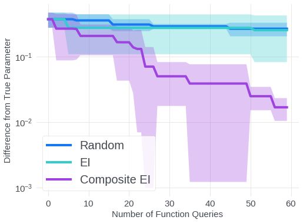

```python
plt.figure(figsize = (8,6))
labels_dict = {"rnd": "Random", "ei": "EI", "ei_hogp_cf": "Composite EI"}
for k in models_used:
    plt.plot(
        torch.arange(n_batches * batch_size),
        mean_and_sem_results[k][0],
        label = labels_dict[k],
    )

    plt.fill_between(
        torch.arange(n_batches * batch_size),
        (mean_and_sem_results[k][0] - mean_and_sem_results[k][1]).clamp(min=1e-3),
        mean_and_sem_results[k][0] + mean_and_sem_results[k][1],
        alpha = 0.3
    )
plt.legend(fontsize = 20)
plt.semilogy()
plt.xlabel("Number of Function Queries")
plt.ylabel("Difference from True Parameter")
```

Download Tutorial Jupyter Notebook

Download Tutorial Source Code